# 时空模型检测PM2.5异常值报告

### 一、背景：人工标签存在不足

对空气污染数据的实时浓度进行异常标注是空气质量监测的重要工作之一。高效、正确、有意义的标签能够帮助监测人员及时发现异常，也能够指导空气监测地点进行空气质量改善工作。然而，目前气象观测站点现行的打标签模式为人工模式，即每个站点各自挑选多位工作人员，根据自身经验，对污染物数据进行异常标注。上述打标签模式可能存在以下问题：

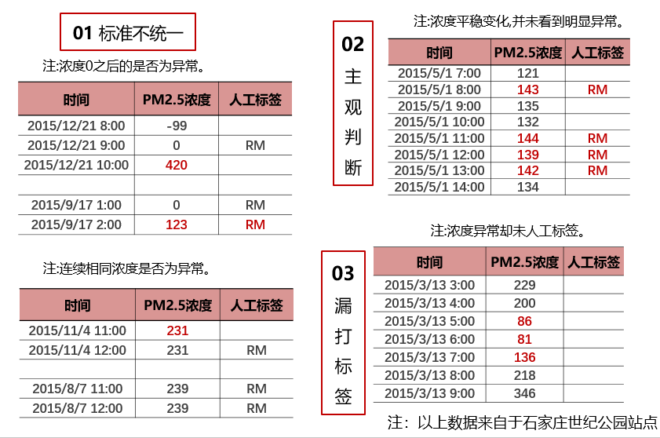

  图1：人工标签存在的问题

[figure not shown]

图2：空间一致性异常

基于人工标签存在的上述问题，我们希望建立一套自动化打标签的方法以代替人工标签，从而实现以下几点目的：

- **自动分类多种异常类型**。
- **实现自动化，增强时效性**。
- **标注污染物空间上的不一致**。

### 二、模型建立

图3展示了我们的建模流程。 总体来看，我们的整体模型由两个子回归构成：（1）全模型回归；（2）只含空间变量的回归。其中，全模型的因变量为当前时刻的PM2.5浓度，自变量包含前一时刻PM2.5浓度，同时刻附近其他站点PM2.5浓度均值，同时刻其他污染物浓度。图4展示了全模型回归的公式。而只含空间变量的回归较为简单，即因变量为当前时刻的PM2.5浓度，自变量只包含同时刻附近其他站点PM2.5浓度均值。

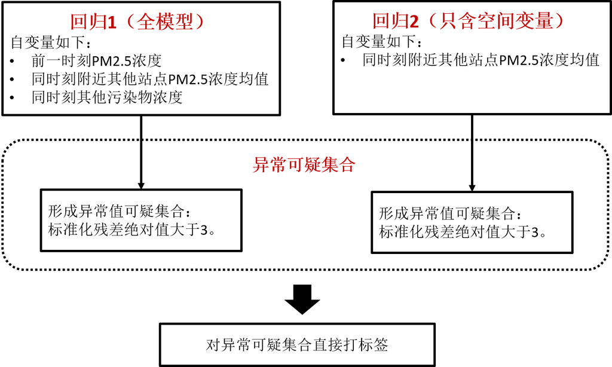

图3：建模流程

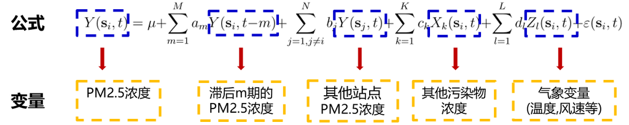

图4：全模型回归

基于上述两个重要的自回归，我们首先，对模型进行训练与拟合。之后针对模型的残差值进行检测，我们将异常值进行标准化后绝对值依然大于3的观测判定为异常值。图5展示了一个以残差值为3判断异常值的示例。针对找到的异常值，可以依据不同的标准对异常值进行分类并打标签，分为以下五个类别：

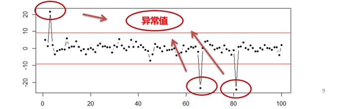

  图5：残差图示例

### 三、 模型效果检测

#### 1. 石家庄污染物异常值检测

表1：石家庄2015年1-6月异常值检测

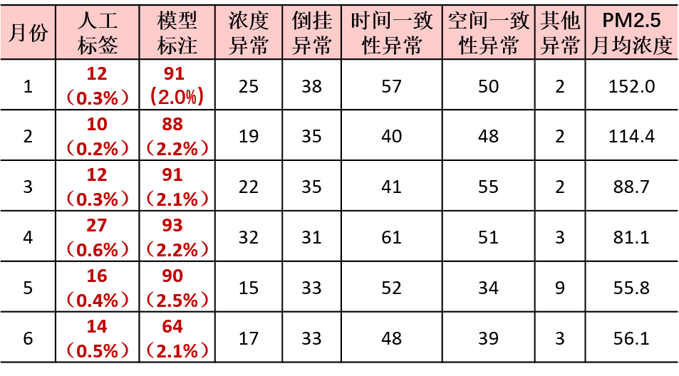

表2：石家庄2015年1-6月异常值覆盖率

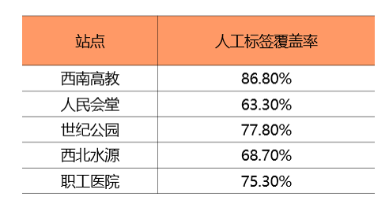

表3：西安市2016年2月份异常值检测

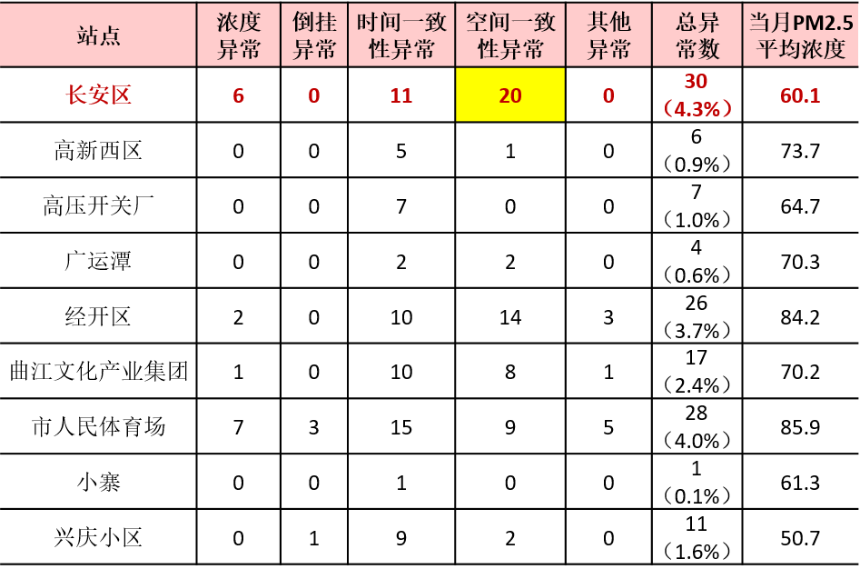

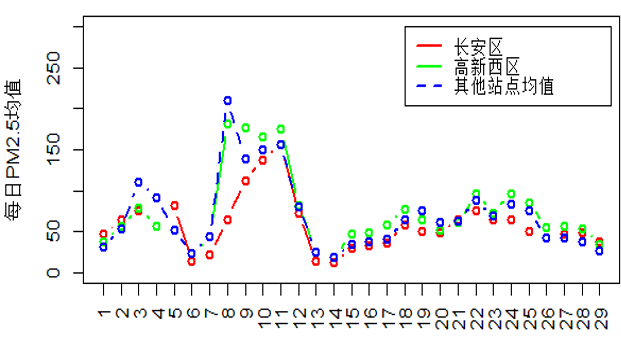

图6：2016年2月长安区PM2.5浓度比较图

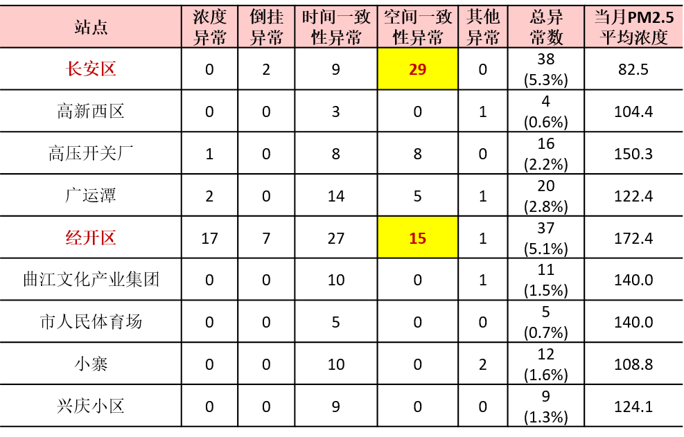

表3：西安市2016年11月异常值检测

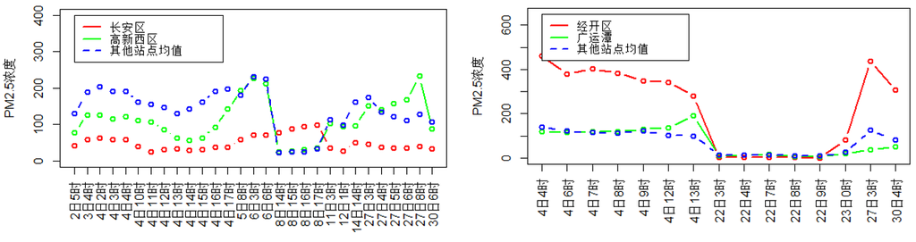

图7：2016年11月长安区、经开区PM2.5浓度比较图